# Beyond the AUC, part 2: the real data

External validation of the Ontario gestational age model in Bangladesh and Zambia

Author

Steven Hawken

Published

October 28, 2026

**About these data**

The Zambia and Bangladesh newborn screening data are **openly available** on Dryad ([doi:10.5061/dryad.m37pvmd6b](https://doi.org/10.5061/dryad.m37pvmd6b)). The reference GA is from a first-trimester dating ultrasound. The Ontario development data cannot be shared, but the **fitted Ontario models** are used here exactly as they were for the published external validations. Minor differences from published numbers are expected because missing analytes are handled more simply here: batch-mean imputation instead of multiple imputation.

# 1 Setup

```r
# install.packages(c("dplyr", "tidyr", "forcats", "ggplot2", "glmnet", "glmnetUtils"))
library(dplyr)
library(tidyr)
library(ggplot2)
library(glmnetUtils)
library(splines)

source("code/ga_functions.R")   # original pipeline (prep.data, pareto_log, ...)
source("code/gavars.R")         # original derived variables (af_ratio, SGA, ...)
source("code/ga_preprocess.R")  # frozen preprocessing (section 4)
source("R/metrics.R")           # AUC with DeLong CI, etc.
source("R/plots.R")             # theme and palette
source("R/real_data.R")         # loading and scoring helpers

options(width = 200)
pct <- function(x, d = 1) sprintf(paste0("%.", d, "f%%"), 100 * x)

full_model <- readRDS("code/full_model_pto_relax.rds")  # Ontario: clinical + analytes
bw_model   <- readRDS("code/bw_model_pto_relax.rds")    # Ontario: birthweight, sex, multiple
cohorts    <- load_all_cohorts("data")
```

# 2 Meet the data

## 2.1 Four cohorts, two countries, two sample types

```r
bind_rows(cohorts) |>
  group_by(Cohort = cohort) |>
  summarise(n = n(),
            `Preterm (<37 wk)` = sprintf("%d (%s)", sum(preterm01), pct(mean(preterm01))),
            `<34 wk` = sum(gestage < 34),
            `SGA (<10th)` = pct(mean(sga10 == 1)),
            `Median birthweight (g)` = median(bweight_raw),
            Multiples = sum(multiple == "multiple"),
            .groups = "drop") |>
  arrange(match(Cohort, COHORTS$cohort))
```

| Cohort | n | Preterm (<37 wk) | <34 wk | SGA (<10th) | Median birthweight (g) | Multiples |
| --- | --- | --- | --- | --- | --- | --- |
| Bangladesh heel | 520 | 35 (6.7%) | 3 | 28.3% | 2845 | 7 |
| Bangladesh cord | 1139 | 108 (9.5%) | 7 | 25.1% | 2890 | 19 |
| Zambia heel | 142 | 11 (7.7%) | 2 | 7.7% | 3100 | 8 |
| Zambia cord | 265 | 22 (8.3%) | 6 | 9.4% | 3150 | 9 |

Preterm infants are **rare** in every cohort: 11 in Zambia heel samples, 35 in Bangladesh heel samples. Keep that in mind when you see the confidence intervals below.

## 2.2 Birthweight for gestational age differs between the two countries

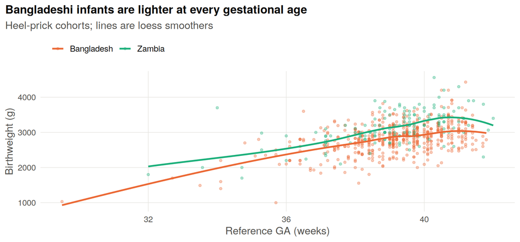

```r
heel <- bind_rows(cohorts[c("Bangladesh heel", "Zambia heel")])
ggplot(heel, aes(gestage, bweight_raw, colour = country)) +
  geom_point(alpha = 0.35, size = 1.2) +
  geom_smooth(method = "loess", se = FALSE, linewidth = 1, formula = y ~ x) +
  scale_colour_manual(values = COL_COUNTRY) +
  labs(x = "Reference GA (weeks)", y = "Birthweight (g)",
       title = "Bangladeshi infants are lighter at every gestational age",
       subtitle = "Heel-prick cohorts; lines are loess smoothers") +
  theme_seminar()
```

About 1 in 4 Bangladeshi infants is small for gestational age, against about 1 in 12 in Zambia. A model that leans on birthweight will **underestimate GA** wherever growth restriction is common.

## 2.3 Which analytes track gestational age?

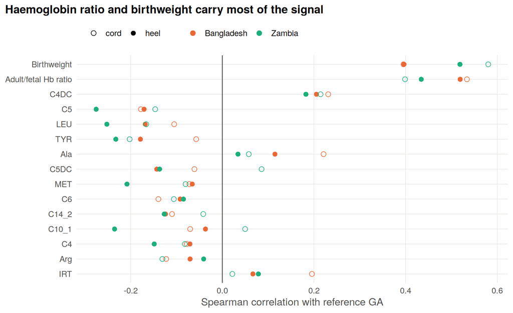

```r
num_vars <- c("bweight_raw", "af_ratio", LOG_VARS)
cors <- bind_rows(lapply(names(cohorts), function(k) {
  d <- cohorts[[k]]
  data.frame(cohort = k, variable = num_vars,
             rho = sapply(num_vars, function(v)
               cor(d[[v]], d$gestage, method = "spearman", use = "complete.obs")))
}))
top <- cors |> group_by(variable) |> summarise(m = mean(abs(rho))) |>
  slice_max(m, n = 15) |> pull(variable)
cors |>
  filter(variable %in% top) |>
  mutate(variable = factor(variable, levels = rev(top)),
         variable = forcats::fct_recode(variable, Birthweight = "bweight_raw",
                                        `Adult/fetal Hb ratio` = "af_ratio"),
         country = sub(" .*", "", cohort), sample = sub(".* ", "", cohort)) |>
  ggplot(aes(rho, variable, colour = country, shape = sample)) +
  geom_vline(xintercept = 0, colour = INK2) +
  geom_point(size = 2.6) +
  scale_colour_manual(values = COL_COUNTRY) +
  scale_shape_manual(values = c(heel = 16, cord = 1)) +
  labs(x = "Spearman correlation with reference GA", y = NULL,
       title = "Haemoglobin ratio and birthweight carry most of the signal") +
  theme_seminar()
```

Only the adult/fetal haemoglobin ratio and birthweight correlate with GA beyond |ρ| ≈ 0.3. The rest of the model’s accuracy comes from combining many weak signals, which is why it uses penalised regression.

## 2.4 Heel and cord blood are different samples

The same infants often gave both a heel-prick and a cord-blood sample, so we can compare the two directly:

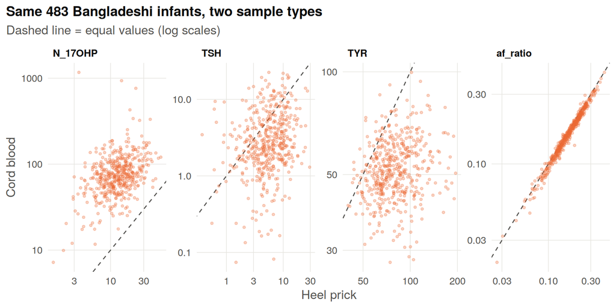

```r
pairs_bd <- inner_join(
  cohorts[["Bangladesh heel"]] |> select(pair_id, gestage, N_17OHP, TSH, TYR, af_ratio),
  cohorts[["Bangladesh cord"]] |> select(pair_id, N_17OHP, TSH, TYR, af_ratio),
  by = "pair_id", suffix = c("_heel", "_cord"))
pairs_long <- bind_rows(lapply(c("N_17OHP", "TSH", "TYR", "af_ratio"), function(v)
  data.frame(analyte = v, heel = pairs_bd[[paste0(v, "_heel")]],
             cord = pairs_bd[[paste0(v, "_cord")]])))
pairs_long |>
  filter(heel > 0, cord > 0) |>
  ggplot(aes(heel, cord)) +
  geom_abline(colour = INK2, linetype = "dashed") +
  geom_point(alpha = 0.3, size = 1, colour = COL_COUNTRY[["Bangladesh"]]) +
  scale_x_log10() + scale_y_log10() +
  facet_wrap(~ analyte, scales = "free", nrow = 1) +
  labs(x = "Heel prick", y = "Cord blood",
       title = sprintf("Same %d Bangladeshi infants, two sample types", nrow(pairs_bd)),
       subtitle = "Dashed line = equal values (log scales)") +
  theme_seminar()
```

17-OHP is about five times higher in cord blood, while TSH and tyrosine are lower. A model trained on heel-prick samples sees cord blood as a **shifted population**, even for the very same infant.

## 2.5 Laboratory and population differences between countries

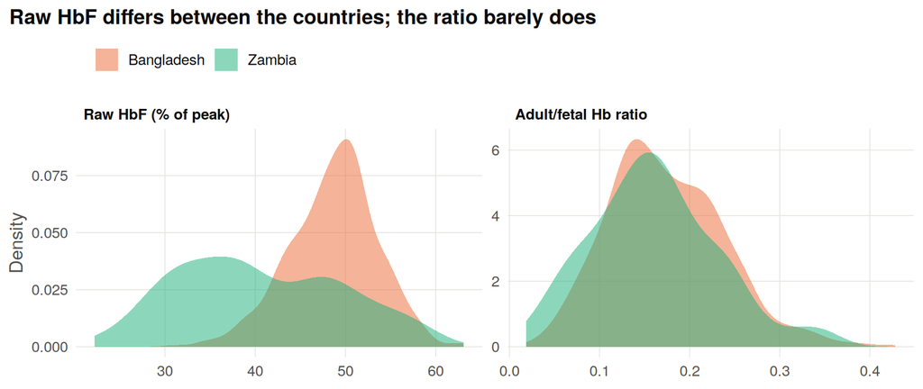

```r
heel |>
  select(country, `Raw HbF (% of peak)` = HGB_F, `Adult/fetal Hb ratio` = af_ratio) |>
  pivot_longer(-country) |>
  mutate(name = factor(name, levels = c("Raw HbF (% of peak)", "Adult/fetal Hb ratio"))) |>
  ggplot(aes(value, fill = country)) +
  geom_density(alpha = 0.5, colour = NA) +
  facet_wrap(~ name, scales = "free") +
  scale_fill_manual(values = COL_COUNTRY) +
  labs(x = NULL, y = "Density",
       title = "Raw HbF differs between the countries; the ratio barely does") +
  theme_seminar()
```

A **ratio** of two measurements from the same run cancels much of the between-laboratory calibration difference. Feature choices affect transportability.

## 2.6 Data quality

```r
bind_rows(lapply(names(cohorts), function(k) {
  d <- cohorts[[k]]
  data.frame(cohort = k, variable = c("af_ratio", LOG_VARS),
             missing = sapply(c("af_ratio", LOG_VARS), function(v) mean(is.na(d[[v]]))))
})) |>
  filter(missing > 0.05) |>
  mutate(missing = pct(missing)) |>
  pivot_wider(names_from = cohort, values_from = missing, values_fill = "<5%")
```

| variable | Zambia heel | Zambia cord |
| --- | --- | --- |
| af_ratio | 14.1% | 30.9% |
| N_17OHP | 10.6% | 10.6% |
| TREC | 16.9% | <5% |
| bio | 45.1% | 7.5% |
| GALT | 50.7% | 44.5% |
| IRT | 33.8% | 10.6% |
| TSH | 6.3% | 10.2% |

```r
sapply(cohorts, function(d) sum(d$TSH <= 0, na.rm = TRUE))   # non-positive TSH values
```

```
Bangladesh heel Bangladesh cord     Zambia heel     Zambia cord
              0              14               9              15
```

Zambia has substantial missingness for several analytes, and some TSH values are ≤ 0 (below the detection limit). External data are rarely as clean as the development data.

# 3 External validation of the Ontario model

Both Ontario models are applied exactly as in the published validations. Each cohort is standardised on itself before scoring (see section 4).

```r
for (k in names(cohorts)) {
  cohorts[[k]]$pred_full <- score_site_standardised(cohorts[[k]], full_model, alpha = 0.75)
  cohorts[[k]]$pred_bw   <- score_site_standardised(cohorts[[k]], bw_model)
}
```

## 3.1 Accuracy, with bootstrap confidence intervals

```r
perf_tab <- bind_rows(lapply(names(cohorts), function(k) {
  d <- cohorts[[k]]
  bind_rows(lapply(c(`Clinical + analytes` = "pred_full",
                     `Birthweight, sex, multiple` = "pred_bw"), function(v) {
    b <- boot_perf(d$gestage, d[[v]], B = 1000)
    g <- function(m) b[b$metric == m, ]
    data.frame(
      Cohort = k, n = nrow(d),
      `MAE (wk)` = with(g("MAE"), fmt_ci(estimate, lower, upper)),
      `Within 7 days` = with(g("within_7d"), fmt_ci(estimate, lower, upper, d = 0, pct = TRUE)),
      `Bias (wk)` = with(g("bias"), fmt_ci(estimate, lower, upper)),
      `MAE preterm` = with(g("MAE_preterm"), fmt_ci(estimate, lower, upper)),
      check.names = FALSE)
  }), .id = "Model")
}))
perf_tab |> relocate(Cohort, Model)
```

| Cohort | Model | n | MAE (wk) | Within 7 days | Bias (wk) | MAE preterm |
| --- | --- | --- | --- | --- | --- | --- |
| Bangladesh heel | Clinical + analytes | 520 | 0.80 (0.74 to 0.85) | 68 (64 to 72) | 0.00 (-0.09 to 0.09) | 1.35 (1.02 to 1.69) |
| Bangladesh heel | Birthweight, sex, multiple | 520 | 1.14 (1.05 to 1.24) | 57 (53 to 61) | -0.12 (-0.26 to 0.01) | 2.49 (1.88 to 3.21) |
| Bangladesh cord | Clinical + analytes | 1139 | 0.95 (0.90 to 0.99) | 59 (56 to 62) | 0.12 (0.05 to 0.19) | 1.75 (1.57 to 1.94) |
| Bangladesh cord | Birthweight, sex, multiple | 1139 | 1.13 (1.07 to 1.19) | 56 (53 to 59) | 0.09 (0.01 to 0.18) | 2.10 (1.81 to 2.40) |
| Zambia heel | Clinical + analytes | 142 | 0.79 (0.69 to 0.90) | 72 (64 to 79) | -0.07 (-0.24 to 0.11) | 1.35 (0.96 to 1.91) |
| Zambia heel | Birthweight, sex, multiple | 142 | 1.22 (1.01 to 1.49) | 58 (49 to 66) | -0.27 (-0.56 to 0.02) | 3.96 (2.76 to 5.40) |
| Zambia cord | Clinical + analytes | 265 | 1.06 (0.95 to 1.17) | 58 (52 to 64) | 0.04 (-0.11 to 0.21) | 2.49 (1.88 to 3.13) |
| Zambia cord | Birthweight, sex, multiple | 265 | 1.06 (0.95 to 1.18) | 58 (52 to 65) | -0.02 (-0.18 to 0.16) | 2.53 (1.84 to 3.28) |

- Heel-prick MAE is about 0.8 weeks in both countries, close to the 0.7 weeks in the Ontario test set. Cord blood is worse.
- The confidence intervals for **preterm infants** are wide: 11–35 preterm infants per heel cohort is not enough to pin down subgroup accuracy.

## 3.2 Calibration and regression to the mean

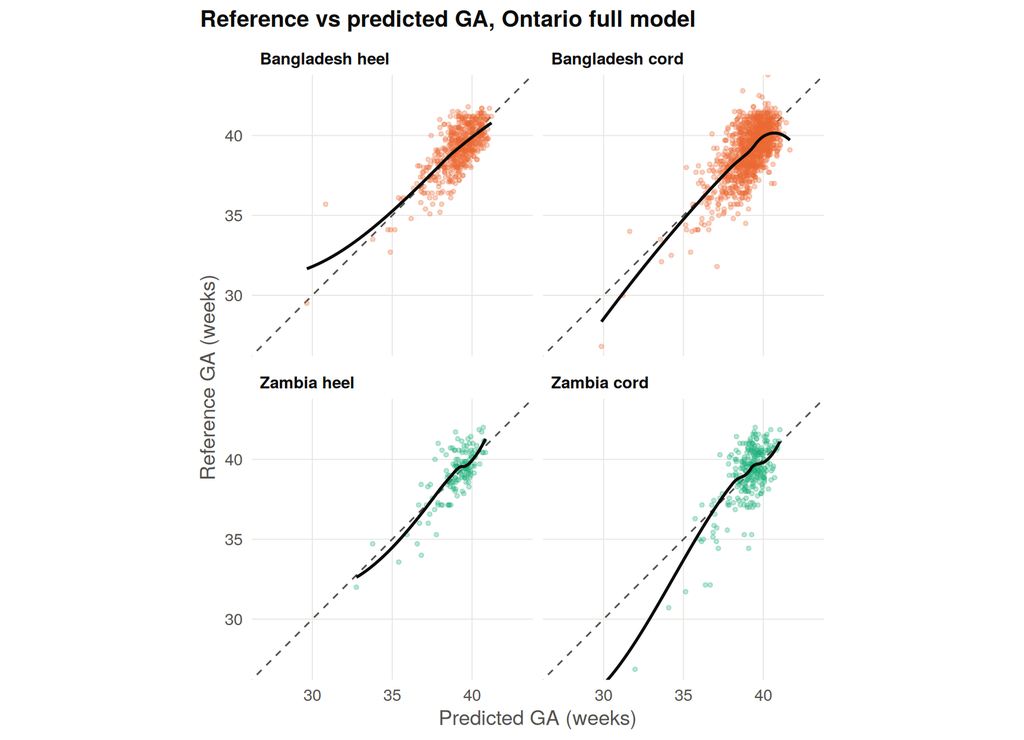

```r
all_scored <- bind_rows(cohorts) |>
  mutate(cohort = factor(cohort, levels = COHORTS$cohort))
ggplot(all_scored, aes(pred_full, gestage)) +
  geom_abline(colour = INK2, linetype = "dashed") +
  geom_point(aes(colour = country), alpha = 0.3, size = 1, show.legend = FALSE) +
  geom_smooth(method = "loess", se = FALSE, colour = INK, linewidth = 0.9,
              formula = y ~ x) +
  facet_wrap(~ cohort, nrow = 2) +
  scale_colour_manual(values = COL_COUNTRY) +
  coord_equal(xlim = c(27, 43), ylim = c(27, 43)) +
  labs(x = "Predicted GA (weeks)", y = "Reference GA (weeks)",
       title = "Reference vs predicted GA, Ontario full model") +
  theme_seminar()
```

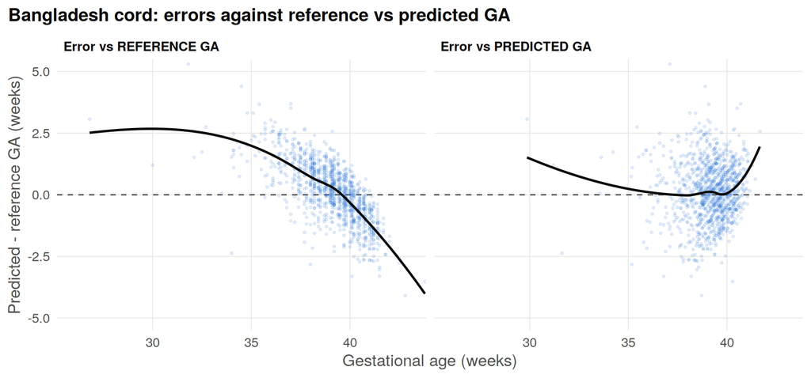

```r
plot_regression_to_mean(rename(cohorts[["Bangladesh cord"]], ga_ref = gestage),
                        pred = "pred_full") +
  labs(title = "Bangladesh cord: errors against reference vs predicted GA")
```

This is the same pattern as in the simulation: infants **born** preterm are predicted too old (left), because of regression to the mean.

## 3.3 Where the analytes earn their keep: small-for-gestational-age infants

```r
bind_rows(cohorts) |>
  mutate(group = ifelse(sga10 == 1, "SGA (<10th centile)", "Not SGA")) |>
  group_by(Cohort = cohort, group) |>
  summarise(n = n(),
            `Bias, birthweight model` = mean(pred_bw - gestage),
            `Bias, full model` = mean(pred_full - gestage),
            `MAE, birthweight model` = mean(abs(pred_bw - gestage)),
            `MAE, full model` = mean(abs(pred_full - gestage)), .groups = "drop") |>
  mutate(across(where(is.double), \(x) round(x, 2))) |>
  arrange(match(Cohort, COHORTS$cohort), desc(group))
```

| Cohort | group | n | Bias, birthweight model | Bias, full model | MAE, birthweight model | MAE, full model |
| --- | --- | --- | --- | --- | --- | --- |
| Bangladesh heel | SGA (<10th centile) | 147 | -1.73 | -0.42 | 1.75 | 0.85 |
| Bangladesh heel | Not SGA | 373 | 0.52 | 0.17 | 0.90 | 0.77 |
| Bangladesh cord | SGA (<10th centile) | 286 | -1.52 | -0.58 | 1.55 | 0.96 |
| Bangladesh cord | Not SGA | 853 | 0.63 | 0.36 | 0.99 | 0.94 |
| Zambia heel | SGA (<10th centile) | 11 | -3.29 | -0.71 | 3.29 | 0.81 |
| Zambia heel | Not SGA | 131 | -0.01 | -0.02 | 1.05 | 0.79 |
| Zambia cord | SGA (<10th centile) | 25 | -2.30 | -0.29 | 2.30 | 1.02 |
| Zambia cord | Not SGA | 240 | 0.22 | 0.08 | 0.93 | 1.06 |

The birthweight model reads growth restriction as immaturity: it underestimates GA in SGA infants by 1.5–3.3 weeks. The metabolic profile largely corrects this. That matters most in settings where SGA is common.

## 3.4 Heel vs cord in the same infants

```r
paired_perf <- function(country) {
  h <- cohorts[[paste(country, "heel")]]; c <- cohorts[[paste(country, "cord")]]
  j <- inner_join(select(h, pair_id, gestage, heel = pred_full),
                  select(c, pair_id, cord = pred_full), by = "pair_id")
  data.frame(Country = country, `Paired infants` = nrow(j),
             `MAE heel` = mean(abs(j$heel - j$gestage)),
             `MAE cord` = mean(abs(j$cord - j$gestage)),
             `Within 7 d, heel` = pct(mean(abs(j$heel - j$gestage) <= 1)),
             `Within 7 d, cord` = pct(mean(abs(j$cord - j$gestage) <= 1)),
             check.names = FALSE)
}
bind_rows(paired_perf("Bangladesh"), paired_perf("Zambia")) |>
  mutate(across(where(is.double), \(x) round(x, 2)))
```

| Country | Paired infants | MAE heel | MAE cord | Within 7 d, heel | Within 7 d, cord |
| --- | --- | --- | --- | --- | --- |
| Bangladesh | 483 | 0.79 | 0.87 | 67.1% | 64.0% |
| Zambia | 96 | 0.79 | 0.89 | 72.9% | 65.6% |

Same infants, same reference GA: the difference is due to the **sample type** alone. That is a measurement shift, not a population shift.

## 3.5 Discrimination for preterm birth

Predicted GA itself is the score: the lower the predicted GA, the more likely preterm.

```r
bind_rows(lapply(names(cohorts), function(k) {
  d <- cohorts[[k]]
  a3 <- auc_ci(d$preterm01, -d$pred_full); a1 <- auc_ci(d$preterm01, -d$pred_bw)
  data.frame(Cohort = k, `Preterm infants` = sum(d$preterm01),
             `AUC, full model` = fmt_ci(a3[1], a3[2], a3[3], 3),
             `AUC, birthweight model` = fmt_ci(a1[1], a1[2], a1[3], 3),
             check.names = FALSE)
}))
```

| Cohort | Preterm infants | AUC, full model | AUC, birthweight model |
| --- | --- | --- | --- |
| Bangladesh heel | 35 | 0.954 (0.930 to 0.978) | 0.839 (0.767 to 0.912) |
| Bangladesh cord | 108 | 0.905 (0.881 to 0.929) | 0.812 (0.766 to 0.858) |
| Zambia heel | 11 | 0.983 (0.965 to 1.000) | 0.813 (0.638 to 0.987) |
| Zambia cord | 22 | 0.947 (0.898 to 0.997) | 0.891 (0.801 to 0.981) |

AUCs are high for the full model everywhere. With so few preterm infants, though, the estimates are imprecise: the birthweight model’s interval in Zambia heel samples runs from about 0.64 to 0.99, and asymptotic intervals such as DeLong’s are themselves unreliable with 11 events. Current guidance for external validation studies is to plan sample size around the **number of events** (often 100 or more) and the precision needed for calibration as well as discrimination (Riley et al., *BMJ* 2024).

## 3.6 Counting preterm births: a surveillance use case

```r
bind_rows(lapply(names(cohorts), function(k) {
  d <- cohorts[[k]]
  data.frame(Cohort = k, `Observed preterm` = pct(mean(d$preterm01)),
             `Predicted GA < 37 wk` = pct(mean(d$pred_full < 37)),
             check.names = FALSE)
}))
```

| Cohort | Observed preterm | Predicted GA < 37 wk |
| --- | --- | --- |
| Bangladesh heel | 6.7% | 4.8% |
| Bangladesh cord | 9.5% | 4.5% |
| Zambia heel | 7.7% | 6.3% |
| Zambia cord | 8.3% | 6.4% |

Counting infants whose **predicted** GA is below 37 weeks underestimates the preterm birth rate, sometimes by half. This is regression to the mean again: predictions are pulled toward term. For population surveillance, estimate the rate by averaging calibrated predicted probabilities, not by counting classifications.

# 4 Does a prediction depend on the batch it is scored in?

The published pipeline standardises each dataset **on itself** before scoring (`prep.data()`), and the model’s spline knots are written as `knots = quantile(x, ...)`, which is re-evaluated on whatever data are being scored. So an infant’s prediction can depend on **who else is in the batch**.

## 4.1 The same infants, scored in different batches

```r
bh <- cohorts[["Bangladesh heel"]]
set.seed(11); idx_random <- sample(nrow(bh), 60)
set.seed(12); idx_enriched <- c(sample(which(bh$preterm01 == 1), 30),
                                sample(which(bh$preterm01 == 0), 30))
batch_df <- bind_rows(
  data.frame(batch = "Random batch of 60",
             full_cohort = bh$pred_full[idx_random],
             own_batch = score_site_standardised(bh[idx_random, ], full_model, 0.75)),
  data.frame(batch = "Batch of 60, half preterm",
             full_cohort = bh$pred_full[idx_enriched],
             own_batch = score_site_standardised(bh[idx_enriched, ], full_model, 0.75)))
batch_df |>
  group_by(batch) |>
  summarise(`Mean shift (wk)` = mean(own_batch - full_cohort),
            `Mean |change| (wk)` = mean(abs(own_batch - full_cohort)),
            `Largest |change| (wk)` = max(abs(own_batch - full_cohort))) |>
  mutate(across(where(is.double), \(x) round(x, 2)))
```

| batch | Mean shift (wk) | Mean \|change\| (wk) | Largest \|change\| (wk) |
| --- | --- | --- | --- |
| Batch of 60, half preterm | 0.86 | 1.00 | 2.57 |
| Random batch of 60 | -0.32 | 0.35 | 2.87 |

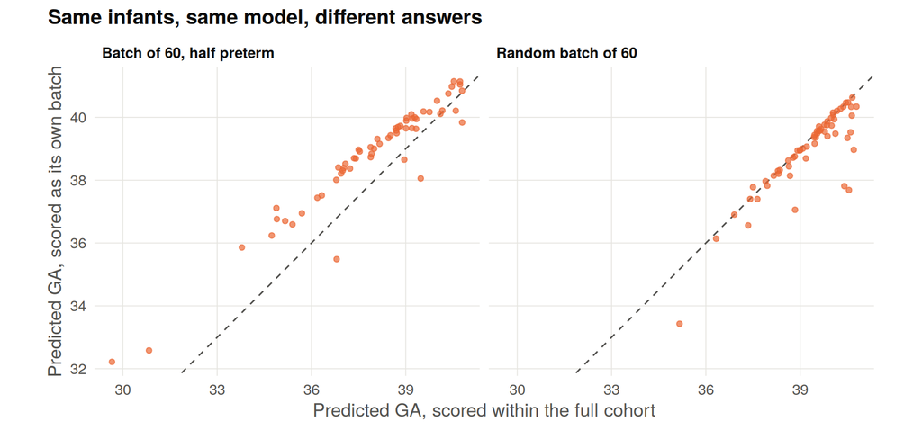

```r
ggplot(batch_df, aes(full_cohort, own_batch)) +
  geom_abline(colour = INK2, linetype = "dashed") +
  geom_point(colour = COL_COUNTRY[["Bangladesh"]], alpha = 0.7) +
  facet_wrap(~ batch) + coord_equal() +
  labs(x = "Predicted GA, scored within the full cohort",
       y = "Predicted GA, scored as its own batch",
       title = "Same infants, same model, different answers") +
  theme_seminar()
```

## 4.2 The fix: learn every constant once, in the reference data

`code/ga_preprocess.R` stores the floor, winsorisation cap, centre, scale and spline knots from the reference data, and applies them unchanged. Until the Ontario constants are available, the **Bangladesh heel cohort stands in as the reference** to demonstrate the mechanics:

```r
ref_raw <- cohorts[["Bangladesh heel"]]
prep_ref <- ga_prep_fit(ref_raw, LOG_VARS, NOLOG_VARS,
                        reference_label = "Bangladesh heel (stand-in)")
set.seed(1); ref_pto <- prep.data(ref_raw)
fit_rows <- complete.cases(ref_pto[, c(LOG_VARS, NOLOG_VARS)])
knots_ref <- ga_knots_fit(ref_pto[fit_rows, ], SPLINE_VARS, type = "bs_range")
bundle_ref <- ga_bundle(ga_freeze_terms(full_model, knots_ref), prep_ref,
                        knots_ref, alpha = 0.75)
check_batch_invariance(bundle_ref, cohorts[["Zambia heel"]], n = 40)
```

```
max_abs_diff_subsets   single_infant_diff
                   0                    0
```

The frozen constants also give a **covariate-shift table**: how far each variable in a new cohort is from the reference, in reference SD units. Look at it before looking at outcomes.

```r
shift_top <- function(target, label) {
  ga_shift(ga_prep_apply(cohorts[[target]], prep_ref)) |>
    head(6) |>
    transmute(Comparison = label, variable,
              `SMD vs reference` = round(smd_vs_reference, 2),
              `% outside reference range` = pct(pct_below_ref + pct_above_ref))
}
bind_rows(shift_top("Zambia heel", "Zambia heel (other site)"),
          shift_top("Bangladesh cord", "Bangladesh cord (other sample type)"))
```

| Comparison | variable | SMD vs reference | % outside reference range |
| --- | --- | --- | --- |
| Zambia heel (other site) | C2 | -2.50 | 38.0% |
| Zambia heel (other site) | Orn | -1.68 | 10.6% |
| Zambia heel (other site) | Cit | -1.36 | 6.3% |
| Zambia heel (other site) | C3 | -1.36 | 16.2% |
| Zambia heel (other site) | Gly | -1.31 | 23.2% |
| Zambia heel (other site) | GALT | -1.28 | 7.1% |
| Bangladesh cord (other sample type) | N_17OHP | 2.89 | 44.1% |
| Bangladesh cord (other sample type) | C14_1 | -2.64 | 9.2% |
| Bangladesh cord (other sample type) | C12_1 | -2.60 | 0.0% |
| Bangladesh cord (other sample type) | C12 | -2.43 | 15.8% |
| Bangladesh cord (other sample type) | C14 | -2.40 | 1.6% |
| Bangladesh cord (other sample type) | C18_1 | -2.17 | 15.6% |

```r
# Runs once the Ontario constants have been released from ICES
ont_bundle <- readRDS("code/full_model_frozen_bundle.rds")
bind_rows(lapply(names(cohorts), function(k) {
  d <- cohorts[[k]]
  p <- predict_ga(ont_bundle, d, impute = "reference_mean")
  data.frame(Cohort = k,
             `MAE, site-standardised` = mean(abs(d$pred_full - d$gestage)),
             `MAE, Ontario-frozen` = mean(abs(p - d$gestage)),
             `Bias, site-standardised` = mean(d$pred_full - d$gestage),
             `Bias, Ontario-frozen` = mean(p - d$gestage), check.names = FALSE)
})) |>
  mutate(across(where(is.double), \(x) round(x, 2)))
```

# 5 What we would do differently next time

**Lessons from this case study**

1. **The model is the whole pipeline.** Learn every preprocessing constant in the training data only, store it with the coefficients, and test that predictions do not depend on the batch.
2. **Store spline knots as numbers**, and prefer restricted (natural) cubic splines, which are linear beyond the outer knots, for models that will travel. B-splines extrapolate as unconstrained cubics.
3. **Look at covariate shift before outcomes**: sample type, laboratory, population.
4. **If you standardise per site, do it on purpose.** Describe it as part of the model and test its sensitivity to batch composition.
5. **Plan external validation sample sizes around events**, not participants.
6. **Justify class-imbalance weights**, and report calibration.
7. **Report the model as coded**, following TRIPOD+AI.

# 6 References

- Hawken S, et al. Development and external validation of machine learning algorithms for postnatal gestational age estimation using clinical data and metabolomic markers. *PLOS ONE* 2023. Data: Dryad, doi:10.5061/dryad.m37pvmd6b.
- Riley RD, Archer L, Snell KIE, et al. Evaluation of clinical prediction models (part 3): calculating the sample size required for an external validation study. *BMJ* 2024.
- Collins GS, et al. TRIPOD+AI statement. *BMJ* 2024.